# LGEO2185: Session ? – RF classification with tidymodels

## 2. EDA (exploration + quality checks)

### 2.1 Inspect columns + class label

The observed landcover classes in the database are given in the column `class`. Let’s explore what we have:

```r
# What are the unique classes?
table(kasai_df$class, useNA = "ifany")
```

```
built_up cropland   forest savannah    water
     212      361      246      265      234
```

### 2.2 Missing values and obvious issues

```r
# Count NAs per column (largest first)
na_counts <- sort(colSums(is.na(kasai_df)), decreasing = TRUE)
head(na_counts, 20)
```

```
      date       site       year       yymm      class polygon_id         B2
         0          0          0          0          0          0          0
        B3         B4         B5         B6         B7         B8        B8A
         0          0          0          0          0          0          0
       B11        B12        BSI       NDVI        EVI
         0          0          0          0          0
```

It looks like our database is fully populated.

### 2.3 Quick sanity plot

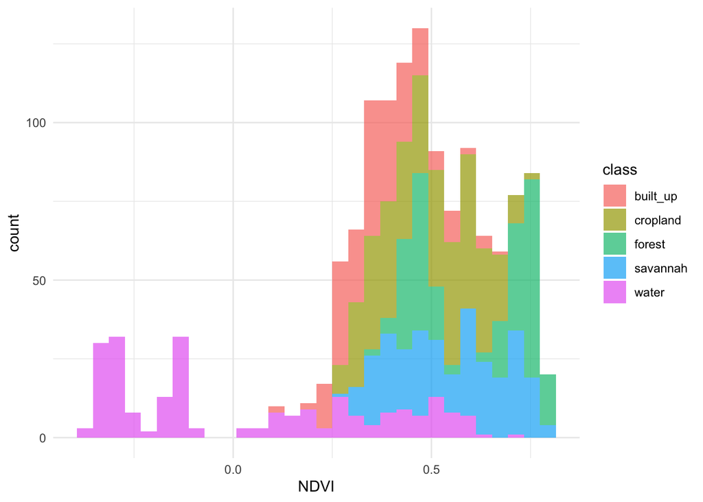

```r
# Example: NDVI
if ("NDVI" %in% names(kasai_df)) {
  ggplot(kasai_df, aes(x = NDVI, fill = class)) +
    geom_histogram(bins = 30, alpha = 0.7) +
    theme_minimal()
}
```

What do we see here? built-up mostly under 0.5 and confirms mixed pixels as it aggregates houses + trees and gardens. Note overlap between cropland and savannah, this points to the need to look at multiple predictors.

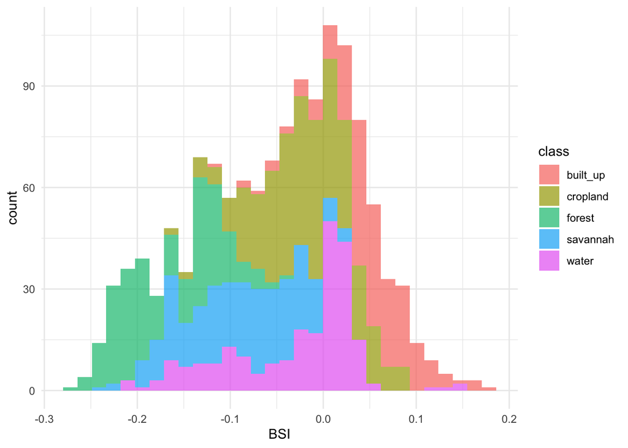

```r
# Example: BSI
if ("BSI" %in% names(kasai_df)) {
  ggplot(kasai_df, aes(x = BSI, fill = class)) +
    geom_histogram(bins = 30, alpha = 0.7) +
    theme_minimal()
}
```

**Note**

Now we are getting to the core. The tidymodels standardizes the steps you do again and again—splitting, pre-processing, training, tuning, and evaluation.

A helpful overview is:

- ** 3 `rsample`**: how you create training/test sets and resamples (folds)
- ** 4 `recipes`**: how you define preprocessing steps
- ** 5`parsnip`**: a consistent interface to many model engines (e.g., `ranger`)
- ** 6 `workflows`**: bundle recipe + model into a single object you can fit
- ** 7-9 `tune`**: systematic tuning across resamples
- ** 10-11 `yardstick`**: model performance metrics (classification + regression)